# Risk Factor Analysis

## Outcome Variable

**Outcome Variable:** ever_stunted

## Predictor Variables

**Intervention Variable:** impfloor

**Adjustment Set:**

- arm
- W_mage
- meducyrs
- feducyrs
- hhwealth_quart
- hfoodsec
- W_mhtcm
- W_mwtkg
- W_mbmi
- W_nrooms
- W_nchldlt5
- W_parity
- impsan
- safeh20
- delta_W_mage
- delta_meducyrs
- delta_feducyrs
- delta_hhwealth_quart
- delta_hfoodsec
- delta_W_mhtcm
- delta_W_mwtkg
- delta_W_mbmi
- delta_W_nrooms
- delta_W_nchldlt5
- delta_W_parity
- delta_impsan
- delta_safeh20

## Stratifying Variables

The analysis was stratified on these variable(s):

- agecat
- studyid
- country

## Data Summary

| agecat | studyid | country | impfloor | ever_stunted | n_cell | n |
| --- | --- | --- | --- | --- | --- | --- |
| 0-24 months (no birth st.) | CMC-V-BCS-2002 | INDIA | 1 | 0 | 21 | 198 |
| 0-24 months (no birth st.) | CMC-V-BCS-2002 | INDIA | 1 | 1 | 177 | 198 |
| 0-24 months (no birth st.) | CMC-V-BCS-2002 | INDIA | 0 | 0 | 0 | 198 |
| 0-24 months (no birth st.) | CMC-V-BCS-2002 | INDIA | 0 | 1 | 0 | 198 |
| 0-24 months (no birth st.) | CONTENT | PERU | 1 | 0 | 150 | 195 |
| 0-24 months (no birth st.) | CONTENT | PERU | 1 | 1 | 32 | 195 |
| 0-24 months (no birth st.) | CONTENT | PERU | 0 | 0 | 12 | 195 |
| 0-24 months (no birth st.) | CONTENT | PERU | 0 | 1 | 1 | 195 |
| 0-24 months (no birth st.) | GMS-Nepal | NEPAL | 1 | 0 | 50 | 453 |
| 0-24 months (no birth st.) | GMS-Nepal | NEPAL | 1 | 1 | 42 | 453 |
| 0-24 months (no birth st.) | GMS-Nepal | NEPAL | 0 | 0 | 148 | 453 |
| 0-24 months (no birth st.) | GMS-Nepal | NEPAL | 0 | 1 | 213 | 453 |
| 0-24 months (no birth st.) | IRC | INDIA | 1 | 0 | 123 | 270 |
| 0-24 months (no birth st.) | IRC | INDIA | 1 | 1 | 147 | 270 |
| 0-24 months (no birth st.) | IRC | INDIA | 0 | 0 | 0 | 270 |
| 0-24 months (no birth st.) | IRC | INDIA | 0 | 1 | 0 | 270 |
| 0-24 months (no birth st.) | JiVitA-3 | BANGLADESH | 1 | 0 | 1375 | 18325 |
| 0-24 months (no birth st.) | JiVitA-3 | BANGLADESH | 1 | 1 | 279 | 18325 |
| 0-24 months (no birth st.) | JiVitA-3 | BANGLADESH | 0 | 0 | 12329 | 18325 |
| 0-24 months (no birth st.) | JiVitA-3 | BANGLADESH | 0 | 1 | 4342 | 18325 |
| 0-24 months (no birth st.) | JiVitA-4 | BANGLADESH | 1 | 0 | 361 | 3874 |
| 0-24 months (no birth st.) | JiVitA-4 | BANGLADESH | 1 | 1 | 154 | 3874 |
| 0-24 months (no birth st.) | JiVitA-4 | BANGLADESH | 0 | 0 | 1908 | 3874 |
| 0-24 months (no birth st.) | JiVitA-4 | BANGLADESH | 0 | 1 | 1451 | 3874 |
| 0-24 months (no birth st.) | MAL-ED | BANGLADESH | 1 | 0 | 85 | 203 |
| 0-24 months (no birth st.) | MAL-ED | BANGLADESH | 1 | 1 | 101 | 203 |
| 0-24 months (no birth st.) | MAL-ED | BANGLADESH | 0 | 0 | 8 | 203 |
| 0-24 months (no birth st.) | MAL-ED | BANGLADESH | 0 | 1 | 9 | 203 |
| 0-24 months (no birth st.) | MAL-ED | BRAZIL | 1 | 0 | 152 | 185 |
| 0-24 months (no birth st.) | MAL-ED | BRAZIL | 1 | 1 | 31 | 185 |

[output cut: 162 more lines]

The following strata were considered:

- agecat: 0-24 months (no birth st.), studyid: CMC-V-BCS-2002, country: INDIA
- agecat: 0-24 months (no birth st.), studyid: CONTENT, country: PERU
- agecat: 0-24 months (no birth st.), studyid: GMS-Nepal, country: NEPAL
- agecat: 0-24 months (no birth st.), studyid: IRC, country: INDIA
- agecat: 0-24 months (no birth st.), studyid: JiVitA-3, country: BANGLADESH
- agecat: 0-24 months (no birth st.), studyid: JiVitA-4, country: BANGLADESH
- agecat: 0-24 months (no birth st.), studyid: MAL-ED, country: BANGLADESH
- agecat: 0-24 months (no birth st.), studyid: MAL-ED, country: BRAZIL
- agecat: 0-24 months (no birth st.), studyid: MAL-ED, country: INDIA
- agecat: 0-24 months (no birth st.), studyid: MAL-ED, country: NEPAL
- agecat: 0-24 months (no birth st.), studyid: MAL-ED, country: PERU
- agecat: 0-24 months (no birth st.), studyid: MAL-ED, country: SOUTH AFRICA
- agecat: 0-24 months (no birth st.), studyid: MAL-ED, country: TANZANIA, UNITED REPUBLIC OF
- agecat: 0-24 months (no birth st.), studyid: NIH-Birth, country: BANGLADESH
- agecat: 0-24 months (no birth st.), studyid: NIH-Crypto, country: BANGLADESH
- agecat: 0-24 months (no birth st.), studyid: PROVIDE, country: BANGLADESH
- agecat: 0-6 months (no birth st.), studyid: CMC-V-BCS-2002, country: INDIA
- agecat: 0-6 months (no birth st.), studyid: CONTENT, country: PERU
- agecat: 0-6 months (no birth st.), studyid: GMS-Nepal, country: NEPAL
- agecat: 0-6 months (no birth st.), studyid: IRC, country: INDIA
- agecat: 0-6 months (no birth st.), studyid: JiVitA-3, country: BANGLADESH
- agecat: 0-6 months (no birth st.), studyid: JiVitA-4, country: BANGLADESH
- agecat: 0-6 months (no birth st.), studyid: MAL-ED, country: BANGLADESH
- agecat: 0-6 months (no birth st.), studyid: MAL-ED, country: BRAZIL
- agecat: 0-6 months (no birth st.), studyid: MAL-ED, country: INDIA
- agecat: 0-6 months (no birth st.), studyid: MAL-ED, country: NEPAL
- agecat: 0-6 months (no birth st.), studyid: MAL-ED, country: PERU
- agecat: 0-6 months (no birth st.), studyid: MAL-ED, country: SOUTH AFRICA
- agecat: 0-6 months (no birth st.), studyid: MAL-ED, country: TANZANIA, UNITED REPUBLIC OF
- agecat: 0-6 months (no birth st.), studyid: NIH-Birth, country: BANGLADESH
- agecat: 0-6 months (no birth st.), studyid: NIH-Crypto, country: BANGLADESH
- agecat: 0-6 months (no birth st.), studyid: PROVIDE, country: BANGLADESH
- agecat: 6-24 months, studyid: CMC-V-BCS-2002, country: INDIA
- agecat: 6-24 months, studyid: CONTENT, country: PERU
- agecat: 6-24 months, studyid: GMS-Nepal, country: NEPAL
- agecat: 6-24 months, studyid: IRC, country: INDIA
- agecat: 6-24 months, studyid: JiVitA-3, country: BANGLADESH
- agecat: 6-24 months, studyid: JiVitA-4, country: BANGLADESH
- agecat: 6-24 months, studyid: MAL-ED, country: BANGLADESH
- agecat: 6-24 months, studyid: MAL-ED, country: BRAZIL
- agecat: 6-24 months, studyid: MAL-ED, country: INDIA
- agecat: 6-24 months, studyid: MAL-ED, country: NEPAL
- agecat: 6-24 months, studyid: MAL-ED, country: PERU
- agecat: 6-24 months, studyid: MAL-ED, country: SOUTH AFRICA
- agecat: 6-24 months, studyid: MAL-ED, country: TANZANIA, UNITED REPUBLIC OF
- agecat: 6-24 months, studyid: NIH-Birth, country: BANGLADESH
- agecat: 6-24 months, studyid: NIH-Crypto, country: BANGLADESH
- agecat: 6-24 months, studyid: PROVIDE, country: BANGLADESH

### Dropped Strata

Some strata were dropped due to rare outcomes:

- agecat: 0-24 months (no birth st.), studyid: CMC-V-BCS-2002, country: INDIA
- agecat: 0-24 months (no birth st.), studyid: CONTENT, country: PERU
- agecat: 0-24 months (no birth st.), studyid: IRC, country: INDIA
- agecat: 0-24 months (no birth st.), studyid: MAL-ED, country: BRAZIL
- agecat: 0-24 months (no birth st.), studyid: MAL-ED, country: INDIA
- agecat: 0-24 months (no birth st.), studyid: MAL-ED, country: TANZANIA, UNITED REPUBLIC OF
- agecat: 0-6 months (no birth st.), studyid: CMC-V-BCS-2002, country: INDIA
- agecat: 0-6 months (no birth st.), studyid: CONTENT, country: PERU
- agecat: 0-6 months (no birth st.), studyid: IRC, country: INDIA
- agecat: 0-6 months (no birth st.), studyid: MAL-ED, country: BANGLADESH
- agecat: 0-6 months (no birth st.), studyid: MAL-ED, country: BRAZIL
- agecat: 0-6 months (no birth st.), studyid: MAL-ED, country: INDIA
- agecat: 0-6 months (no birth st.), studyid: MAL-ED, country: NEPAL
- agecat: 0-6 months (no birth st.), studyid: MAL-ED, country: TANZANIA, UNITED REPUBLIC OF
- agecat: 6-24 months, studyid: CMC-V-BCS-2002, country: INDIA
- agecat: 6-24 months, studyid: CONTENT, country: PERU
- agecat: 6-24 months, studyid: IRC, country: INDIA
- agecat: 6-24 months, studyid: MAL-ED, country: BRAZIL
- agecat: 6-24 months, studyid: MAL-ED, country: INDIA
- agecat: 6-24 months, studyid: MAL-ED, country: TANZANIA, UNITED REPUBLIC OF

## Methods Detail

We’re interested in the causal parameters $E[Y_a]$ for all values of $a \in \mathcal{A}$. These parameters represent the mean outcome if, possibly contrary to fact, we intervened to set all units to have $A=a$. Under the randomization and positivity assumptions, these are identified by the statistical parameters $\psi_a=E_W[E_{Y|A,W}(Y|A=a,W)]$. In addition, we’re interested in the mean of $Y$, $E[Y]$ under no intervention (the observed mean). We will estimate these parameters by using SuperLearner to fit the relevant likelihood factors – $E_{Y|A,W}(Y|A=a,W)$ and $p(A=a|W)$, and then updating our likelihood fit using a joint TMLE.

For unadjusted analyses ($W=\{\}$), initial likelihoods were estimated using Lrnr_glm to estimate the simple $E(Y|A)$ and Lrnr_mean to estimate $p(A)$. For adjusted analyses, a small library containing Lrnr_glmnet, Lrnr_xgboost, and Lrnr_mean was used.

Having estimated these parameters, we will then use the delta method to estimate relative risks and attributable risks relative to a prespecified baseline level of $A$.

# Results Detail

## Results Plots

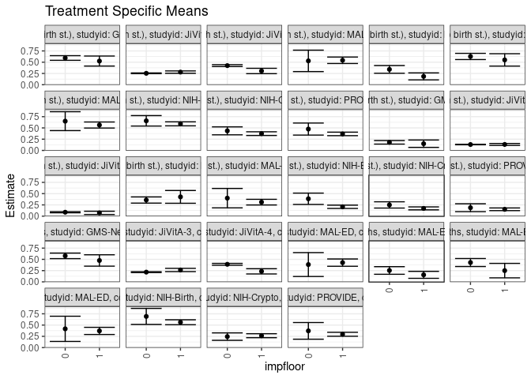

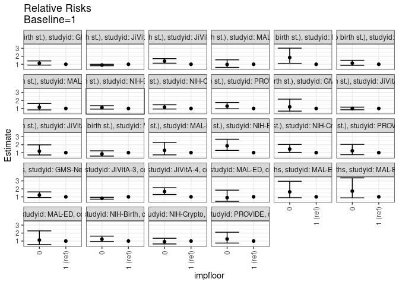

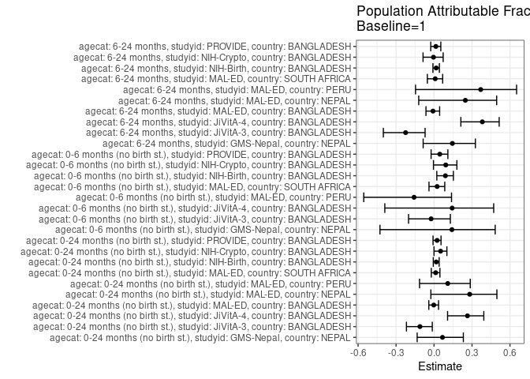

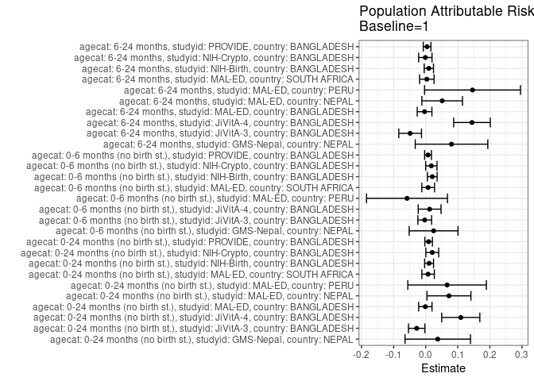

## Results Table

### Parameter: TSM

| agecat | studyid | country | intervention_level | baseline_level | estimate | ci_lower | ci_upper |
| --- | --- | --- | --- | --- | --- | --- | --- |
| 0-24 months (no birth st.) | GMS-Nepal | NEPAL | 1 | NA | 0.5253241 | 0.4140957 | 0.6365524 |
| 0-24 months (no birth st.) | GMS-Nepal | NEPAL | 0 | NA | 0.5934769 | 0.5421983 | 0.6447556 |
| 0-24 months (no birth st.) | JiVitA-3 | BANGLADESH | 1 | NA | 0.2802184 | 0.2542207 | 0.3062161 |
| 0-24 months (no birth st.) | JiVitA-3 | BANGLADESH | 0 | NA | 0.2531408 | 0.2450669 | 0.2612146 |
| 0-24 months (no birth st.) | JiVitA-4 | BANGLADESH | 1 | NA | 0.3049832 | 0.2455299 | 0.3644364 |
| 0-24 months (no birth st.) | JiVitA-4 | BANGLADESH | 0 | NA | 0.4239981 | 0.4030498 | 0.4449463 |
| 0-24 months (no birth st.) | MAL-ED | BANGLADESH | 1 | NA | 0.5430108 | 0.4712444 | 0.6147772 |
| 0-24 months (no birth st.) | MAL-ED | BANGLADESH | 0 | NA | 0.5294118 | 0.2915562 | 0.7672673 |
| 0-24 months (no birth st.) | MAL-ED | NEPAL | 1 | NA | 0.1849112 | 0.1074480 | 0.2623744 |
| 0-24 months (no birth st.) | MAL-ED | NEPAL | 0 | NA | 0.3403362 | 0.2546033 | 0.4260690 |
| 0-24 months (no birth st.) | MAL-ED | PERU | 1 | NA | 0.5509088 | 0.4133208 | 0.6884968 |
| 0-24 months (no birth st.) | MAL-ED | PERU | 0 | NA | 0.6274703 | 0.5585347 | 0.6964059 |
| 0-24 months (no birth st.) | MAL-ED | SOUTH AFRICA | 1 | NA | 0.5645933 | 0.4972273 | 0.6319593 |
| 0-24 months (no birth st.) | MAL-ED | SOUTH AFRICA | 0 | NA | 0.6500000 | 0.4405048 | 0.8594952 |
| 0-24 months (no birth st.) | NIH-Birth | BANGLADESH | 1 | NA | 0.5906276 | 0.5461312 | 0.6351240 |
| 0-24 months (no birth st.) | NIH-Birth | BANGLADESH | 0 | NA | 0.6575448 | 0.5415453 | 0.7735444 |
| 0-24 months (no birth st.) | NIH-Crypto | BANGLADESH | 1 | NA | 0.3730908 | 0.3318962 | 0.4142853 |
| 0-24 months (no birth st.) | NIH-Crypto | BANGLADESH | 0 | NA | 0.4346375 | 0.3466716 | 0.5226033 |
| 0-24 months (no birth st.) | PROVIDE | BANGLADESH | 1 | NA | 0.3668983 | 0.3275925 | 0.4062041 |
| 0-24 months (no birth st.) | PROVIDE | BANGLADESH | 0 | NA | 0.4744032 | 0.3409350 | 0.6078714 |
| 0-6 months (no birth st.) | GMS-Nepal | NEPAL | 1 | NA | 0.1497743 | 0.0676288 | 0.2319198 |
| 0-6 months (no birth st.) | GMS-Nepal | NEPAL | 0 | NA | 0.1801651 | 0.1406204 | 0.2197097 |
| 0-6 months (no birth st.) | JiVitA-3 | BANGLADESH | 1 | NA | 0.1331745 | 0.1113350 | 0.1550140 |
| 0-6 months (no birth st.) | JiVitA-3 | BANGLADESH | 0 | NA | 0.1311699 | 0.1251835 | 0.1371563 |
| 0-6 months (no birth st.) | JiVitA-4 | BANGLADESH | 1 | NA | 0.0732299 | 0.0373336 | 0.1091262 |
| 0-6 months (no birth st.) | JiVitA-4 | BANGLADESH | 0 | NA | 0.0867950 | 0.0743753 | 0.0992147 |
| 0-6 months (no birth st.) | MAL-ED | PERU | 1 | NA | 0.4280714 | 0.2863776 | 0.5697652 |
| 0-6 months (no birth st.) | MAL-ED | PERU | 0 | NA | 0.3584433 | 0.2899802 | 0.4269064 |
| 0-6 months (no birth st.) | MAL-ED | SOUTH AFRICA | 1 | NA | 0.3110048 | 0.2481097 | 0.3738999 |
| 0-6 months (no birth st.) | MAL-ED | SOUTH AFRICA | 0 | NA | 0.4000000 | 0.1848264 | 0.6151736 |
| 0-6 months (no birth st.) | NIH-Birth | BANGLADESH | 1 | NA | 0.2082022 | 0.1715911 | 0.2448133 |
| 0-6 months (no birth st.) | NIH-Birth | BANGLADESH | 0 | NA | 0.3861485 | 0.2605247 | 0.5117723 |
| 0-6 months (no birth st.) | NIH-Crypto | BANGLADESH | 1 | NA | 0.1722954 | 0.1393289 | 0.2052619 |
| 0-6 months (no birth st.) | NIH-Crypto | BANGLADESH | 0 | NA | 0.2493295 | 0.1797729 | 0.3188861 |
| 0-6 months (no birth st.) | PROVIDE | BANGLADESH | 1 | NA | 0.1523233 | 0.1228074 | 0.1818393 |
| 0-6 months (no birth st.) | PROVIDE | BANGLADESH | 0 | NA | 0.1877294 | 0.1003506 | 0.2751081 |
| 6-24 months | GMS-Nepal | NEPAL | 1 | NA | 0.4747470 | 0.3485992 | 0.6008948 |
| 6-24 months | GMS-Nepal | NEPAL | 0 | NA | 0.5775429 | 0.5160268 | 0.6390591 |
| 6-24 months | JiVitA-3 | BANGLADESH | 1 | NA | 0.2646211 | 0.2283878 | 0.3008545 |
| 6-24 months | JiVitA-3 | BANGLADESH | 0 | NA | 0.2163407 | 0.2064243 | 0.2262571 |
| 6-24 months | JiVitA-4 | BANGLADESH | 1 | NA | 0.2339545 | 0.1758693 | 0.2920397 |
| 6-24 months | JiVitA-4 | BANGLADESH | 0 | NA | 0.3898725 | 0.3688265 | 0.4109184 |
| 6-24 months | MAL-ED | BANGLADESH | 1 | NA | 0.4275862 | 0.3468051 | 0.5083673 |
| 6-24 months | MAL-ED | BANGLADESH | 0 | NA | 0.3846154 | 0.1193126 | 0.6499181 |
| 6-24 months | MAL-ED | NEPAL | 1 | NA | 0.1561242 | 0.0787396 | 0.2335088 |
| 6-24 months | MAL-ED | NEPAL | 0 | NA | 0.2533527 | 0.1690479 | 0.3376576 |
| 6-24 months | MAL-ED | PERU | 1 | NA | 0.2500000 | 0.0890719 | 0.4109281 |
| 6-24 months | MAL-ED | PERU | 0 | NA | 0.4297521 | 0.3412490 | 0.5182552 |
| 6-24 months | MAL-ED | SOUTH AFRICA | 1 | NA | 0.3706294 | 0.2912132 | 0.4500455 |
| 6-24 months | MAL-ED | SOUTH AFRICA | 0 | NA | 0.4166667 | 0.1368228 | 0.6965105 |
| 6-24 months | NIH-Birth | BANGLADESH | 1 | NA | 0.5628931 | 0.5082955 | 0.6174907 |
| 6-24 months | NIH-Birth | BANGLADESH | 0 | NA | 0.6923077 | 0.5146429 | 0.8699725 |
| 6-24 months | NIH-Crypto | BANGLADESH | 1 | NA | 0.2639756 | 0.2201483 | 0.3078030 |
| 6-24 months | NIH-Crypto | BANGLADESH | 0 | NA | 0.2440806 | 0.1617763 | 0.3263849 |
| 6-24 months | PROVIDE | BANGLADESH | 1 | NA | 0.2960678 | 0.2526110 | 0.3395246 |
| 6-24 months | PROVIDE | BANGLADESH | 0 | NA | 0.3712159 | 0.1863510 | 0.5560808 |

### Parameter: E(Y)

| agecat | studyid | country | intervention_level | baseline_level | estimate | ci_lower | ci_upper |
| --- | --- | --- | --- | --- | --- | --- | --- |
| 0-24 months (no birth st.) | GMS-Nepal | NEPAL | NA | NA | 0.5629139 | 0.5171858 | 0.6086420 |
| 0-24 months (no birth st.) | JiVitA-3 | BANGLADESH | NA | NA | 0.2521692 | 0.2444469 | 0.2598915 |
| 0-24 months (no birth st.) | JiVitA-4 | BANGLADESH | NA | NA | 0.4143005 | 0.3961166 | 0.4324844 |
| 0-24 months (no birth st.) | MAL-ED | BANGLADESH | NA | NA | 0.5418719 | 0.4731628 | 0.6105810 |
| 0-24 months (no birth st.) | MAL-ED | NEPAL | NA | NA | 0.2574257 | 0.1969827 | 0.3178687 |
| 0-24 months (no birth st.) | MAL-ED | PERU | NA | NA | 0.6176471 | 0.5557776 | 0.6795165 |
| 0-24 months (no birth st.) | MAL-ED | SOUTH AFRICA | NA | NA | 0.5720524 | 0.5078289 | 0.6362759 |
| 0-24 months (no birth st.) | NIH-Birth | BANGLADESH | NA | NA | 0.6011342 | 0.5593675 | 0.6429009 |
| 0-24 months (no birth st.) | NIH-Crypto | BANGLADESH | NA | NA | 0.3935681 | 0.3560687 | 0.4310676 |
| 0-24 months (no birth st.) | PROVIDE | BANGLADESH | NA | NA | 0.3759874 | 0.3382238 | 0.4137509 |
| 0-6 months (no birth st.) | GMS-Nepal | NEPAL | NA | NA | 0.1743929 | 0.1394121 | 0.2093738 |
| 0-6 months (no birth st.) | JiVitA-3 | BANGLADESH | NA | NA | 0.1301898 | 0.1246228 | 0.1357568 |
| 0-6 months (no birth st.) | JiVitA-4 | BANGLADESH | NA | NA | 0.0854560 | 0.0740923 | 0.0968198 |
| 0-6 months (no birth st.) | MAL-ED | PERU | NA | NA | 0.3697479 | 0.3082891 | 0.4312067 |
| 0-6 months (no birth st.) | MAL-ED | SOUTH AFRICA | NA | NA | 0.3187773 | 0.2582893 | 0.3792652 |
| 0-6 months (no birth st.) | NIH-Birth | BANGLADESH | NA | NA | 0.2287335 | 0.1929075 | 0.2645595 |
| 0-6 months (no birth st.) | NIH-Crypto | BANGLADESH | NA | NA | 0.1898928 | 0.1597870 | 0.2199986 |
| 0-6 months (no birth st.) | PROVIDE | BANGLADESH | NA | NA | 0.1595577 | 0.1310079 | 0.1881074 |
| 6-24 months | GMS-Nepal | NEPAL | NA | NA | 0.5552050 | 0.5004138 | 0.6099963 |
| 6-24 months | JiVitA-3 | BANGLADESH | NA | NA | 0.2161001 | 0.2067207 | 0.2254795 |
| 6-24 months | JiVitA-4 | BANGLADESH | NA | NA | 0.3782597 | 0.3596753 | 0.3968440 |
| 6-24 months | MAL-ED | BANGLADESH | NA | NA | 0.4240506 | 0.3467471 | 0.5013542 |
| 6-24 months | MAL-ED | NEPAL | NA | NA | 0.2074468 | 0.1493309 | 0.2655627 |
| 6-24 months | MAL-ED | PERU | NA | NA | 0.3959732 | 0.3171819 | 0.4747644 |
| 6-24 months | MAL-ED | SOUTH AFRICA | NA | NA | 0.3741935 | 0.2977649 | 0.4506221 |
| 6-24 months | NIH-Birth | BANGLADESH | NA | NA | 0.5726744 | 0.5203223 | 0.6250266 |
| 6-24 months | NIH-Crypto | BANGLADESH | NA | NA | 0.2628459 | 0.2244546 | 0.3012371 |
| 6-24 months | PROVIDE | BANGLADESH | NA | NA | 0.3004386 | 0.2583143 | 0.3425629 |

### Parameter: RR

| agecat | studyid | country | intervention_level | baseline_level | estimate | ci_lower | ci_upper |
| --- | --- | --- | --- | --- | --- | --- | --- |
| 0-24 months (no birth st.) | GMS-Nepal | NEPAL | 1 | 1 | 1.0000000 | 1.0000000 | 1.000000 |
| 0-24 months (no birth st.) | GMS-Nepal | NEPAL | 0 | 1 | 1.1297349 | 0.8981548 | 1.421026 |
| 0-24 months (no birth st.) | JiVitA-3 | BANGLADESH | 1 | 1 | 1.0000000 | 1.0000000 | 1.000000 |
| 0-24 months (no birth st.) | JiVitA-3 | BANGLADESH | 0 | 1 | 0.9033695 | 0.8202367 | 0.994928 |
| 0-24 months (no birth st.) | JiVitA-4 | BANGLADESH | 1 | 1 | 1.0000000 | 1.0000000 | 1.000000 |
| 0-24 months (no birth st.) | JiVitA-4 | BANGLADESH | 0 | 1 | 1.3902342 | 1.1344448 | 1.703698 |
| 0-24 months (no birth st.) | MAL-ED | BANGLADESH | 1 | 1 | 1.0000000 | 1.0000000 | 1.000000 |
| 0-24 months (no birth st.) | MAL-ED | BANGLADESH | 0 | 1 | 0.9749563 | 0.6103754 | 1.557304 |
| 0-24 months (no birth st.) | MAL-ED | NEPAL | 1 | 1 | 1.0000000 | 1.0000000 | 1.000000 |
| 0-24 months (no birth st.) | MAL-ED | NEPAL | 0 | 1 | 1.8405384 | 1.1214492 | 3.020718 |
| 0-24 months (no birth st.) | MAL-ED | PERU | 1 | 1 | 1.0000000 | 1.0000000 | 1.000000 |
| 0-24 months (no birth st.) | MAL-ED | PERU | 0 | 1 | 1.1389732 | 0.8680500 | 1.494453 |
| 0-24 months (no birth st.) | MAL-ED | SOUTH AFRICA | 1 | 1 | 1.0000000 | 1.0000000 | 1.000000 |
| 0-24 months (no birth st.) | MAL-ED | SOUTH AFRICA | 0 | 1 | 1.1512712 | 0.8164327 | 1.623435 |
| 0-24 months (no birth st.) | NIH-Birth | BANGLADESH | 1 | 1 | 1.0000000 | 1.0000000 | 1.000000 |
| 0-24 months (no birth st.) | NIH-Birth | BANGLADESH | 0 | 1 | 1.1132985 | 0.9201874 | 1.346936 |
| 0-24 months (no birth st.) | NIH-Crypto | BANGLADESH | 1 | 1 | 1.0000000 | 1.0000000 | 1.000000 |
| 0-24 months (no birth st.) | NIH-Crypto | BANGLADESH | 0 | 1 | 1.1649644 | 0.9279431 | 1.462527 |
| 0-24 months (no birth st.) | PROVIDE | BANGLADESH | 1 | 1 | 1.0000000 | 1.0000000 | 1.000000 |
| 0-24 months (no birth st.) | PROVIDE | BANGLADESH | 0 | 1 | 1.2930101 | 0.9576888 | 1.745740 |
| 0-6 months (no birth st.) | GMS-Nepal | NEPAL | 1 | 1 | 1.0000000 | 1.0000000 | 1.000000 |
| 0-6 months (no birth st.) | GMS-Nepal | NEPAL | 0 | 1 | 1.2029107 | 0.6668314 | 2.169955 |
| 0-6 months (no birth st.) | JiVitA-3 | BANGLADESH | 1 | 1 | 1.0000000 | 1.0000000 | 1.000000 |
| 0-6 months (no birth st.) | JiVitA-3 | BANGLADESH | 0 | 1 | 0.9849479 | 0.8336836 | 1.163658 |
| 0-6 months (no birth st.) | JiVitA-4 | BANGLADESH | 1 | 1 | 1.0000000 | 1.0000000 | 1.000000 |
| 0-6 months (no birth st.) | JiVitA-4 | BANGLADESH | 0 | 1 | 1.1852392 | 0.7107195 | 1.976577 |
| 0-6 months (no birth st.) | MAL-ED | PERU | 1 | 1 | 1.0000000 | 1.0000000 | 1.000000 |
| 0-6 months (no birth st.) | MAL-ED | PERU | 0 | 1 | 0.8373447 | 0.5711289 | 1.227650 |
| 0-6 months (no birth st.) | MAL-ED | SOUTH AFRICA | 1 | 1 | 1.0000000 | 1.0000000 | 1.000000 |
| 0-6 months (no birth st.) | MAL-ED | SOUTH AFRICA | 0 | 1 | 1.2861538 | 0.7239480 | 2.284959 |
| 0-6 months (no birth st.) | NIH-Birth | BANGLADESH | 1 | 1 | 1.0000000 | 1.0000000 | 1.000000 |
| 0-6 months (no birth st.) | NIH-Birth | BANGLADESH | 0 | 1 | 1.8546803 | 1.2838021 | 2.679416 |
| 0-6 months (no birth st.) | NIH-Crypto | BANGLADESH | 1 | 1 | 1.0000000 | 1.0000000 | 1.000000 |
| 0-6 months (no birth st.) | NIH-Crypto | BANGLADESH | 0 | 1 | 1.4471049 | 1.0333609 | 2.026507 |
| 0-6 months (no birth st.) | PROVIDE | BANGLADESH | 1 | 1 | 1.0000000 | 1.0000000 | 1.000000 |
| 0-6 months (no birth st.) | PROVIDE | BANGLADESH | 0 | 1 | 1.2324398 | 0.7458481 | 2.036484 |
| 6-24 months | GMS-Nepal | NEPAL | 1 | 1 | 1.0000000 | 1.0000000 | 1.000000 |
| 6-24 months | GMS-Nepal | NEPAL | 0 | 1 | 1.2165278 | 0.9130685 | 1.620842 |
| 6-24 months | JiVitA-3 | BANGLADESH | 1 | 1 | 1.0000000 | 1.0000000 | 1.000000 |
| 6-24 months | JiVitA-3 | BANGLADESH | 0 | 1 | 0.8175487 | 0.7092538 | 0.942379 |
| 6-24 months | JiVitA-4 | BANGLADESH | 1 | 1 | 1.0000000 | 1.0000000 | 1.000000 |
| 6-24 months | JiVitA-4 | BANGLADESH | 0 | 1 | 1.6664456 | 1.2930816 | 2.147615 |
| 6-24 months | MAL-ED | BANGLADESH | 1 | 1 | 1.0000000 | 1.0000000 | 1.000000 |
| 6-24 months | MAL-ED | BANGLADESH | 0 | 1 | 0.8995037 | 0.4399460 | 1.839105 |
| 6-24 months | MAL-ED | NEPAL | 1 | 1 | 1.0000000 | 1.0000000 | 1.000000 |
| 6-24 months | MAL-ED | NEPAL | 0 | 1 | 1.6227639 | 0.8916638 | 2.953314 |
| 6-24 months | MAL-ED | PERU | 1 | 1 | 1.0000000 | 1.0000000 | 1.000000 |
| 6-24 months | MAL-ED | PERU | 0 | 1 | 1.7190083 | 0.8744979 | 3.379070 |
| 6-24 months | MAL-ED | SOUTH AFRICA | 1 | 1 | 1.0000000 | 1.0000000 | 1.000000 |
| 6-24 months | MAL-ED | SOUTH AFRICA | 0 | 1 | 1.1242138 | 0.5554961 | 2.275186 |
| 6-24 months | NIH-Birth | BANGLADESH | 1 | 1 | 1.0000000 | 1.0000000 | 1.000000 |
| 6-24 months | NIH-Birth | BANGLADESH | 0 | 1 | 1.2299098 | 0.9348170 | 1.618154 |
| 6-24 months | NIH-Crypto | BANGLADESH | 1 | 1 | 1.0000000 | 1.0000000 | 1.000000 |
| 6-24 months | NIH-Crypto | BANGLADESH | 0 | 1 | 0.9246331 | 0.6350867 | 1.346188 |
| 6-24 months | PROVIDE | BANGLADESH | 1 | 1 | 1.0000000 | 1.0000000 | 1.000000 |
| 6-24 months | PROVIDE | BANGLADESH | 0 | 1 | 1.2538204 | 0.7458361 | 2.107789 |

### Parameter: PAR

| agecat | studyid | country | intervention_level | baseline_level | estimate | ci_lower | ci_upper |
| --- | --- | --- | --- | --- | --- | --- | --- |
| 0-24 months (no birth st.) | GMS-Nepal | NEPAL | 1 | NA | 0.0375898 | -0.0644840 | 0.1396637 |
| 0-24 months (no birth st.) | JiVitA-3 | BANGLADESH | 1 | NA | -0.0280492 | -0.0536428 | -0.0024557 |
| 0-24 months (no birth st.) | JiVitA-4 | BANGLADESH | 1 | NA | 0.1093173 | 0.0498518 | 0.1687828 |
| 0-24 months (no birth st.) | MAL-ED | BANGLADESH | 1 | NA | -0.0011388 | -0.0219512 | 0.0196735 |
| 0-24 months (no birth st.) | MAL-ED | NEPAL | 1 | NA | 0.0725145 | 0.0040178 | 0.1410113 |
| 0-24 months (no birth st.) | MAL-ED | PERU | 1 | NA | 0.0667383 | -0.0557569 | 0.1892335 |
| 0-24 months (no birth st.) | MAL-ED | SOUTH AFRICA | 1 | NA | 0.0074591 | -0.0120133 | 0.0269315 |
| 0-24 months (no birth st.) | NIH-Birth | BANGLADESH | 1 | NA | 0.0105066 | -0.0033722 | 0.0243854 |
| 0-24 months (no birth st.) | NIH-Crypto | BANGLADESH | 1 | NA | 0.0204774 | 0.0004251 | 0.0405297 |
| 0-24 months (no birth st.) | PROVIDE | BANGLADESH | 1 | NA | 0.0090891 | -0.0027436 | 0.0209218 |
| 0-6 months (no birth st.) | GMS-Nepal | NEPAL | 1 | NA | 0.0246187 | -0.0515470 | 0.1007843 |
| 0-6 months (no birth st.) | JiVitA-3 | BANGLADESH | 1 | NA | -0.0029847 | -0.0243914 | 0.0184220 |
| 0-6 months (no birth st.) | JiVitA-4 | BANGLADESH | 1 | NA | 0.0122261 | -0.0233123 | 0.0477645 |
| 0-6 months (no birth st.) | MAL-ED | PERU | 1 | NA | -0.0583235 | -0.1845269 | 0.0678799 |
| 0-6 months (no birth st.) | MAL-ED | SOUTH AFRICA | 1 | NA | 0.0077725 | -0.0120761 | 0.0276211 |
| 0-6 months (no birth st.) | NIH-Birth | BANGLADESH | 1 | NA | 0.0205313 | 0.0053979 | 0.0356647 |
| 0-6 months (no birth st.) | NIH-Crypto | BANGLADESH | 1 | NA | 0.0175974 | -0.0000660 | 0.0352608 |
| 0-6 months (no birth st.) | PROVIDE | BANGLADESH | 1 | NA | 0.0072343 | -0.0033656 | 0.0178343 |
| 6-24 months | GMS-Nepal | NEPAL | 1 | NA | 0.0804580 | -0.0326572 | 0.1935732 |
| 6-24 months | JiVitA-3 | BANGLADESH | 1 | NA | -0.0485211 | -0.0839050 | -0.0131372 |
| 6-24 months | JiVitA-4 | BANGLADESH | 1 | NA | 0.1443052 | 0.0872789 | 0.2013314 |
| 6-24 months | MAL-ED | BANGLADESH | 1 | NA | -0.0035356 | -0.0264284 | 0.0193572 |
| 6-24 months | MAL-ED | NEPAL | 1 | NA | 0.0513226 | -0.0119876 | 0.1146328 |
| 6-24 months | MAL-ED | PERU | 1 | NA | 0.1459732 | -0.0036013 | 0.2955476 |
| 6-24 months | MAL-ED | SOUTH AFRICA | 1 | NA | 0.0035642 | -0.0190404 | 0.0261687 |
| 6-24 months | NIH-Birth | BANGLADESH | 1 | NA | 0.0097813 | -0.0047255 | 0.0242882 |
| 6-24 months | NIH-Crypto | BANGLADESH | 1 | NA | -0.0011298 | -0.0219906 | 0.0197310 |
| 6-24 months | PROVIDE | BANGLADESH | 1 | NA | 0.0043708 | -0.0075536 | 0.0162952 |

### Parameter: PAF

| agecat | studyid | country | intervention_level | baseline_level | estimate | ci_lower | ci_upper |
| --- | --- | --- | --- | --- | --- | --- | --- |
| 0-24 months (no birth st.) | GMS-Nepal | NEPAL | 1 | NA | 0.0667772 | -0.1333705 | 0.2315798 |
| 0-24 months (no birth st.) | JiVitA-3 | BANGLADESH | 1 | NA | -0.1112318 | -0.2179327 | -0.0138788 |
| 0-24 months (no birth st.) | JiVitA-4 | BANGLADESH | 1 | NA | 0.2638599 | 0.1069786 | 0.3931811 |
| 0-24 months (no birth st.) | MAL-ED | BANGLADESH | 1 | NA | -0.0021017 | -0.0412568 | 0.0355811 |
| 0-24 months (no birth st.) | MAL-ED | NEPAL | 1 | NA | 0.2816911 | -0.0249517 | 0.4965932 |
| 0-24 months (no birth st.) | MAL-ED | PERU | 1 | NA | 0.1080524 | -0.1145069 | 0.2861682 |
| 0-24 months (no birth st.) | MAL-ED | SOUTH AFRICA | 1 | NA | 0.0130392 | -0.0216475 | 0.0465482 |
| 0-24 months (no birth st.) | NIH-Birth | BANGLADESH | 1 | NA | 0.0174779 | -0.0059616 | 0.0403714 |
| 0-24 months (no birth st.) | NIH-Crypto | BANGLADESH | 1 | NA | 0.0520301 | -0.0001811 | 0.1015157 |
| 0-24 months (no birth st.) | PROVIDE | BANGLADESH | 1 | NA | 0.0241739 | -0.0078475 | 0.0551779 |
| 0-6 months (no birth st.) | GMS-Nepal | NEPAL | 1 | NA | 0.1411678 | -0.4271923 | 0.4831862 |
| 0-6 months (no birth st.) | JiVitA-3 | BANGLADESH | 1 | NA | -0.0229256 | -0.2013680 | 0.1290122 |
| 0-6 months (no birth st.) | JiVitA-4 | BANGLADESH | 1 | NA | 0.1430689 | -0.3889621 | 0.4713096 |
| 0-6 months (no birth st.) | MAL-ED | PERU | 1 | NA | -0.1577385 | -0.5552135 | 0.1381514 |
| 0-6 months (no birth st.) | MAL-ED | SOUTH AFRICA | 1 | NA | 0.0243823 | -0.0398964 | 0.0846877 |
| 0-6 months (no birth st.) | NIH-Birth | BANGLADESH | 1 | NA | 0.0897607 | 0.0219333 | 0.1528844 |
| 0-6 months (no birth st.) | NIH-Crypto | BANGLADESH | 1 | NA | 0.0926702 | -0.0045524 | 0.1804835 |
| 0-6 months (no birth st.) | PROVIDE | BANGLADESH | 1 | NA | 0.0453398 | -0.0231818 | 0.1092726 |
| 6-24 months | GMS-Nepal | NEPAL | 1 | NA | 0.1449159 | -0.0859457 | 0.3266985 |
| 6-24 months | JiVitA-3 | BANGLADESH | 1 | NA | -0.2245306 | -0.4005066 | -0.0706662 |
| 6-24 months | JiVitA-4 | BANGLADESH | 1 | NA | 0.3814976 | 0.2118130 | 0.5146518 |
| 6-24 months | MAL-ED | BANGLADESH | 1 | NA | -0.0083376 | -0.0638059 | 0.0442385 |
| 6-24 months | MAL-ED | NEPAL | 1 | NA | 0.2474013 | -0.1209731 | 0.4947205 |
| 6-24 months | MAL-ED | PERU | 1 | NA | 0.3686441 | -0.1462161 | 0.6522381 |
| 6-24 months | MAL-ED | SOUTH AFRICA | 1 | NA | 0.0095250 | -0.0527700 | 0.0681338 |
| 6-24 months | NIH-Birth | BANGLADESH | 1 | NA | 0.0170801 | -0.0086615 | 0.0421648 |
| 6-24 months | NIH-Crypto | BANGLADESH | 1 | NA | -0.0042983 | -0.0868814 | 0.0720100 |
| 6-24 months | PROVIDE | BANGLADESH | 1 | NA | 0.0145480 | -0.0259472 | 0.0534448 |